With the first big tournament of the season this weekend, I thought it would be fun to take a look at the current rankings and past results to see if we could make some guesses about who will win the Las Vegas Challenge.

Admittedly, I’m not hugely familiar with how these types of analyses are done for something like ball golf and I don’t have access to a big sophisticated dataset. If possible, it would be nice to include things like who putts better in the wind, distance v. technical courses, injuries, etc etc. But that’s beyond me right now.

Additionally, my day job is to do analysis with ecological data and not really make “predictions”. BUT! All those excuses aside, I figured we could do a little poking around nonetheless.

I operated under a few plain assumptions to determine who I think will win:

- Top players (highest PDGA ratings) will perform well
- Players who have played well at the LVC before will do well
- A player’s performance at the LVC in a recent year is more valuable than an earlier year

Here’s who I think will win ranked in order for both the MPO and the FPO. First is a scrollable table of the rankings I generated and second is a plot that shows you who has over- or under-perform based on their player rating compared to previous LVC finishes. That is, players who “overperform” are those who play better at the LVC than they “should” compared to their PDGA rating. (Granted, there’s only 4 tournaments in the dataset)

Below the tables and figures you can see a description of how I generated my results.

### MPO

| PDGA # | Name | 2020 Ratings Rank | Mean LVC Place | Weighted LVC Place | Times Played | LVC Performance Weight | Weighted Score | Predicted Finish |
| --- | --- | --- | --- | --- | --- | --- | --- | --- |
| 37817 | Mcmahon | 3 | 2.0 | 1.8 | 3 | -1.2 | 9.7 | 1 |
| 38008 | Wysocki | 1 | 3.8 | 4.3 | 4 | 3.3 | 10.6 | 2 |
| 45971 | Heimburg | 2 | 5.5 | 6.1 | 2 | 4.1 | 15.3 | 3 |
| 27523 | Mcbeth | 1 | 6.3 | 7.7 | 3 | 6.7 | 16.3 | 4 |
| 18824 | Sexton | 4 | 6.2 | 5.7 | 4 | 1.7 | 16.4 | 5 |
| 24341 | Leiviska | 8 | 9.2 | 9.4 | 4 | 1.4 | 26.8 | 6 |
| 41760 | Jones | 8 | 6.7 | 6.3 | 3 | -1.7 | 27.7 | 7 |
| 26416 | Brathwaite | 10 | 16.8 | 14.9 | 4 | 4.9 | 46.8 | 8 |
| 38464 | Withers | 5 | 22.0 | 19.5 | 4 | 14.5 | 49.0 | 9 |
| 48346 | Gibson | 8 | 20.3 | 17.7 | 3 | 9.7 | 55.3 | 10 |
| 63765 | Presnell | 11 | 14.0 | 13.2 | 2 | 2.2 | 57.4 | 11 |
| 13864 | Gurthie | 7 | 21.3 | 17.7 | 3 | 10.7 | 60.3 | 12 |
| 44382 | Barela | 18 | 21.0 | 19.2 | 3 | 1.2 | 64.3 | 13 |
| 50401 | Clemons | 12 | 22.3 | 23.1 | 3 | 11.1 | 65.2 | 14 |
| 57493 | Rothlisberger | 24 | 23.0 | 23.0 | 1 | -1.0 | 67.0 | 15 |
| 17295 | Conrad | 11 | 25.3 | 29.0 | 3 | 18.0 | 70.0 | 16 |
| 68835 | Hannum | 17 | 27.0 | 22.1 | 3 | 5.1 | 70.2 | 17 |
| 53332 | Barham | 21 | 20.0 | 21.2 | 3 | 0.2 | 71.3 | 18 |
| 47472 | Keith | 16 | 18.3 | 18.9 | 3 | 2.9 | 71.8 | 19 |
| 66362 | Russell | 19 | 27.8 | 24.4 | 4 | 5.4 | 76.8 | 20 |
| 99053 | Tanner | 38 | 4.0 | 4.0 | 1 | -34.0 | 77.0 | 21 |
| 53565 | Oakley | 17 | 20.8 | 16.4 | 4 | -0.6 | 79.8 | 22 |
| 27171 | Ulibarri | 15 | 28.7 | 35.8 | 3 | 20.8 | 86.7 | 23 |
| 49431 | Castro | 25 | 28.0 | 28.7 | 2 | 3.7 | 87.4 | 24 |
| 121715 | Aderhold | 24 | 13.0 | 13.0 | 1 | -11.0 | 91.0 | 25 |
| 54049 | Turner | 23 | 24.5 | 30.0 | 2 | 7.0 | 91.0 | 25 |
| 26269 | Skellenger | 29 | 29.0 | 29.0 | 1 | 0.0 | 98.0 | 26 |
| 33705 | Koling | 13 | 37.0 | 43.3 | 3 | 30.3 | 102.7 | 27 |
| 59419 | Samson | 41 | 14.0 | 14.0 | 1 | -27.0 | 114.0 | 28 |
| 56555 | Meintsma | 22 | 38.0 | 36.4 | 3 | 14.4 | 116.9 | 29 |

[output cut: 54 more lines]

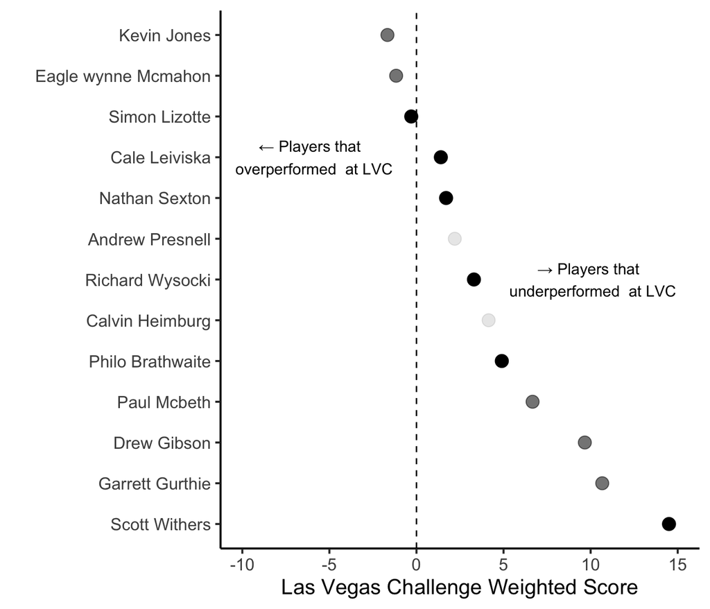

In the plot, players to the left of the dashed line have performed better in past LVCs than expected based on their player rating. Those to the right, have performed worse. Keep in mind the higher ranked a player is, the harder it will be for them to “outperform” their rating - for example since Ricky Wysocki is ranked #1, he would have to have won every LVC to break even.

So it looks like according to the weighted score Eagle McMahon is favored to win. Kevin Jones typically performs a little better at the LVC than other tournaments and comes off his big win at the end of last season.

However, I think given the amount of data here, it’s pretty reasonable to expect anyone in the top ~10 to win and even then someone lower ranked could have a really breakout performance. For example, if the over/under chart had included 30 players, Tristan Tanner would be a huge outlier with a LVC Weighted Score of -34 due to his big performance and 4th place finish last year.

### FPO

| PDGA # | Name | 2020 Ratings Rank | Mean LVC Place | Weighted LVC Place | Times Played | LVC Performance Weight | Weighted Score | Predicted Finish |
| --- | --- | --- | --- | --- | --- | --- | --- | --- |
| 44184 | Allen | 4 | 1.8 | 1.6 | 4 | -2.4 | 6.2 | 1 |
| 29190 | Pierce | 1 | 3.0 | 4.0 | 3 | 3.0 | 10.0 | 2 |
| 34563 | Hokom | 2 | 4.3 | 4.8 | 3 | 2.8 | 13.7 | 3 |
| 15354 | Allen | 6 | 3.7 | 3.8 | 3 | -2.2 | 17.7 | 4 |
| 50656 | Weese | 7 | 6.0 | 5.7 | 4 | -1.3 | 19.4 | 5 |
| 81351 | King | 4 | 6.0 | 6.0 | 1 | 2.0 | 21.0 | 6 |
| 32654 | Fajkus | 13 | 9.5 | 10.4 | 2 | -2.6 | 29.8 | 7 |
| 48976 | Scoggins | 5 | 13.0 | 13.0 | 1 | 8.0 | 31.0 | 8 |
| 59431 | Walker | 13 | 9.2 | 9.3 | 4 | -3.7 | 32.6 | 9 |
| 64751 | McMorran | 16 | 7.5 | 7.1 | 2 | -8.9 | 33.3 | 10 |
| 51229 | Bradley | 10 | 12.0 | 12.0 | 1 | 2.0 | 36.0 | 11 |
| 58303 | Ananda | 17 | 10.5 | 11.0 | 2 | -6.0 | 40.0 | 12 |
| 39504 | Andyke | 11 | 14.5 | 14.8 | 2 | 3.8 | 44.5 | 13 |
| 32917 | Cox | 17 | 14.5 | 13.9 | 4 | -3.1 | 47.8 | 14 |
| 34751 | Bailey | 14 | 13.5 | 14.8 | 2 | 0.8 | 51.5 | 15 |
| 27832 | Panis | 17 | 15.2 | 14.4 | 4 | -2.6 | 58.8 | 16 |
| 60798 | Tomaino | 20 | 17.0 | 17.0 | 1 | -3.0 | 62.0 | 17 |
| 71262 | Stinchcomb | 18 | 16.3 | 15.1 | 3 | -2.9 | 63.3 | 18 |
| 104030 | Allocco | 26 | 18.0 | 18.0 | 1 | -8.0 | 73.0 | 19 |
| 84007 | Maes | 26 | 19.0 | 19.0 | 1 | -7.0 | 94.0 | 20 |
| 63005 | Bilodeau | 26 | 27.0 | 27.0 | 1 | 1.0 | 96.0 | 21 |
| 56987 | Richardson | 26 | 30.0 | 30.0 | 1 | 4.0 | 108.0 | 22 |

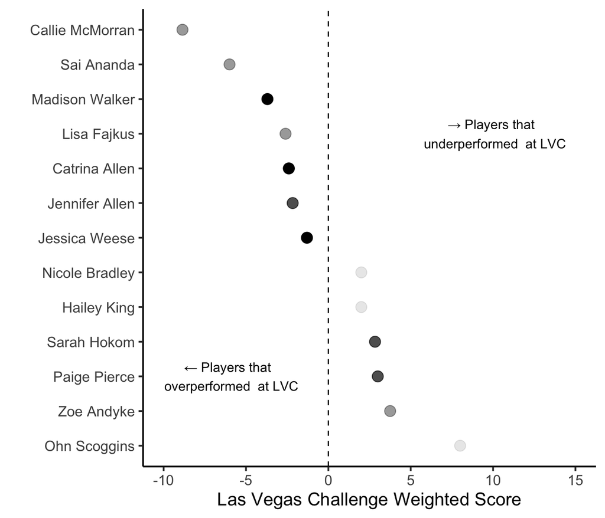

Catrina Allen is favored in the FPO with Paige Pierce right behind her. There are several overperformers in the FPO compared to the MPO, which I found interesting. Probably there is more variability in who succeeds at the LVC in the FPO. Interestingly an email just came from the folks at SkipAce saying their expected overperformer will be Ohn Scoggins due to her spin putting in the wind. My analysis doesn’t capture that, so it will be fun to watch for her play.

Alright! That’s the basic analysis I ran. Hopefully you find it interesting. Because I’ve got this set up now, I’m aiming to in the future add more variables and sophistication into the analysis, maybe have an actual model going. Right now this is pretty simple, but with my limitations in time and current knowledge, we’ll see where it goes.

If you like this, consider [leaving a tip](https://www.buymeacoffee.com/discgolfdata) or using some of the links on the [disc database](https://discgolfdata.com/pages/yadd.html) to purchase discs and help me support my hosting costs.

Peace,

John

To generate the rankings, I did the following things.

First, I gathered the PDGA ratings for all players from 2020. Next, I gathered the results of the past four Las Vegas Challenges (technically called the “Gentlemen’s Club Challenge” in older years). I used the past four simply because I figured only recent events would be reflective and five years ago just seemed *off* when I looked at the results. Subjective, but it’s what I went with.

Taking those basic assumptions I calculated a few things for every player. First, I calculated their “mean place” in previous LVCs (so if they came in 10th once and 6th another time, their mean place = 8). Next, I calculated their *weighted* mean place, basically giving greater importance to more recent LVCs. Each player was then ranked according to their rating in 2020 as well as their ratings at all LVCs. For all of these measurements, a lower score is better (just like disc golf).

Lastly, to give a little more weight to the LVC over just general ratings, I calculated the difference between a players weighted mean LVC placement and their rank position in the 2020 ratings. Players with negative values are therefore expected to typically overperform at the LVC. With all that, we can then calculate a total score (our expectation of who will win given their PDGA rating and past performance at LVC).

Oh - and then I filtered out players who aren’t registered for the tournament (or at least on the waitlist at DGScene).

Whew.